# Competition Tutorial

Mohammed Ali

October 13, 2018

# EDA

## Data Structure

first let take us take a glance for `train` structure

```r
introduce(train)
```

```
##   rows columns discrete_columns continuous_columns all_missing_columns
## 1 1460      81               43                 38                   0
##   total_missing_values total_observations memory_usage
## 1                 6965             118260       516808
```

We can conduct from above the following: * There is a balance betweeen *discreat* and *continous* features. * Nearly 6 % of data is missing. * Let us see how data is organized.

```r
glimpse(train)
```

```
## Observations: 1,460
## Variables: 81
## $ Id            <int> 1, 2, 3, 4, 5, 6, 7, 8, 9, 10, 11, 12, 13, 14, 1...
## $ MSSubClass    <int> 60, 20, 60, 70, 60, 50, 20, 60, 50, 190, 20, 60,...
## $ MSZoning      <fct> RL, RL, RL, RL, RL, RL, RL, RL, RM, RL, RL, RL, ...
## $ LotFrontage   <int> 65, 80, 68, 60, 84, 85, 75, NA, 51, 50, 70, 85, ...
## $ LotArea       <int> 8450, 9600, 11250, 9550, 14260, 14115, 10084, 10...
## $ Street        <fct> Pave, Pave, Pave, Pave, Pave, Pave, Pave, Pave, ...
## $ Alley         <fct> NA, NA, NA, NA, NA, NA, NA, NA, NA, NA, NA, NA, ...
## $ LotShape      <fct> Reg, Reg, IR1, IR1, IR1, IR1, Reg, IR1, Reg, Reg...
## $ LandContour   <fct> Lvl, Lvl, Lvl, Lvl, Lvl, Lvl, Lvl, Lvl, Lvl, Lvl...
## $ Utilities     <fct> AllPub, AllPub, AllPub, AllPub, AllPub, AllPub, ...
## $ LotConfig     <fct> Inside, FR2, Inside, Corner, FR2, Inside, Inside...
## $ LandSlope     <fct> Gtl, Gtl, Gtl, Gtl, Gtl, Gtl, Gtl, Gtl, Gtl, Gtl...
## $ Neighborhood  <fct> CollgCr, Veenker, CollgCr, Crawfor, NoRidge, Mit...
```

[output cut: 68 more lines]

```r
summary(train)
```

```
##        Id           MSSubClass       MSZoning     LotFrontage
##  Min.   :   1.0   Min.   : 20.0   C (all):  10   Min.   : 21.00
##  1st Qu.: 365.8   1st Qu.: 20.0   FV     :  65   1st Qu.: 59.00
##  Median : 730.5   Median : 50.0   RH     :  16   Median : 69.00
##  Mean   : 730.5   Mean   : 56.9   RL     :1151   Mean   : 70.05
##  3rd Qu.:1095.2   3rd Qu.: 70.0   RM     : 218   3rd Qu.: 80.00
##  Max.   :1460.0   Max.   :190.0                  Max.   :313.00
##                                                  NA's   :259
##     LotArea        Street      Alley      LotShape  LandContour
##  Min.   :  1300   Grvl:   6   Grvl:  50   IR1:484   Bnk:  63
##  1st Qu.:  7554   Pave:1454   Pave:  41   IR2: 41   HLS:  50
##  Median :  9478               NA's:1369   IR3: 10   Low:  36
##  Mean   : 10517                           Reg:925   Lvl:1311
##  3rd Qu.: 11602
##  Max.   :215245
##
##   Utilities      LotConfig    LandSlope   Neighborhood   Condition1
##  AllPub:1459   Corner : 263   Gtl:1382   NAmes  :225   Norm   :1260
##  NoSeWa:   1   CulDSac:  94   Mod:  65   CollgCr:150   Feedr  :  81
##                FR2    :  47   Sev:  13   OldTown:113   Artery :  48
##                FR3    :   4              Edwards:100   RRAn   :  26
##                Inside :1052              Somerst: 86   PosN   :  19
##                                          Gilbert: 79   RRAe   :  11
##                                          (Other):707   (Other):  15
##    Condition2     BldgType      HouseStyle   OverallQual
##  Norm   :1445   1Fam  :1220   1Story :726   Min.   : 1.000
##  Feedr  :   6   2fmCon:  31   2Story :445   1st Qu.: 5.000
##  Artery :   2   Duplex:  52   1.5Fin :154   Median : 6.000
##  PosN   :   2   Twnhs :  43   SLvl   : 65   Mean   : 6.099
##  RRNn   :   2   TwnhsE: 114   SFoyer : 37   3rd Qu.: 7.000
##  PosA   :   1                 1.5Unf : 14   Max.   :10.000
##  (Other):   2                 (Other): 19
##   OverallCond      YearBuilt     YearRemodAdd    RoofStyle
##  Min.   :1.000   Min.   :1872   Min.   :1950   Flat   :  13
##  1st Qu.:5.000   1st Qu.:1954   1st Qu.:1967   Gable  :1141
##  Median :5.000   Median :1973   Median :1994   Gambrel:  11
##  Mean   :5.575   Mean   :1971   Mean   :1985   Hip    : 286
##  3rd Qu.:6.000   3rd Qu.:2000   3rd Qu.:2004   Mansard:   7
##  Max.   :9.000   Max.   :2010   Max.   :2010   Shed   :   2
##
```

[output cut: 89 more lines]

```
##  GdPrv:  59   Gar2:   2   Min.   :    0.00   Min.   : 1.000
##  GdWo :  54   Othr:   2   1st Qu.:    0.00   1st Qu.: 5.000
##  MnPrv: 157   Shed:  49   Median :    0.00   Median : 6.000
##  MnWw :  11   TenC:   1   Mean   :   43.49   Mean   : 6.322
##  NA's :1179   NA's:1406   3rd Qu.:    0.00   3rd Qu.: 8.000
##                           Max.   :15500.00   Max.   :12.000
##
##      YrSold        SaleType    SaleCondition    SalePrice
##  Min.   :2006   WD     :1267   Abnorml: 101   Min.   : 34900
##  1st Qu.:2007   New    : 122   AdjLand:   4   1st Qu.:129975
##  Median :2008   COD    :  43   Alloca :  12   Median :163000
##  Mean   :2008   ConLD  :   9   Family :  20   Mean   :180921
##  3rd Qu.:2009   ConLI  :   5   Normal :1198   3rd Qu.:214000
##  Max.   :2010   ConLw  :   5   Partial: 125   Max.   :755000
##                 (Other):   9
```

From above we see: * There are some outliers scattred here and there, we investigate in details in next sections. * The missing observaes are scattred among features, let us investigate that more.

## Missing Data

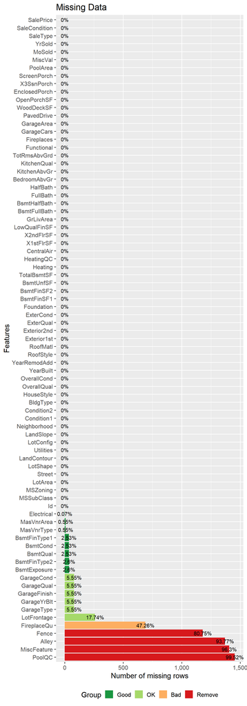

```r
plot_missing(train, title = "Missing Data", ggtheme = theme_gray(base_size = 15))
```

The categorical features with the largest number of missing values are:

- `PoolQC` (99.52%): Pool Quality, no wonder :)
- `MiscFeature` (96.3%): Miscellaneous features not covered in other categories
- `Alley` (93.7%): indicates the type of alley access
- `Fence` (80%): Fence Quality
- `FirePlaceQu` (47.26%): Fireplace quality
- `GarageType` (5.55%): related features
- `GarageYrBlt` (5.55%): I will convert this feature to categorical and treat it like that
- `GarageFinish` (5.55%): Interior finish of the garage
- `GarageQUal` (5.55%): Garage quality
- `GarageCond` (5.55%): Garage condition
- `BsmtExposure` (2.6%): Refers to walkout or garden level walls.
- `BsmtFinType2` (2.6%): Rating of basement finished area (if multiple types)
- `BsmtQual` (2.53%): Evaluates the height of the basement
- `BsmtCond` (2.53%): Evaluates the general condition of the basement
- `BsmtFinType1` (2.53%): Rating of basement finished area
- `MasVnrType` (0.55%): Masonry veneer type

I will Impute categorical features by converting `NA` to *Not available* level except `MasVnrType` I will add level `others` as they must used something to build with.

The missing values indicate that majority of the houses do not have alley access, no pool, no fence and no elevator, 2nd garage, shed or tennis court that is covered by the MiscFeature.

The numeric variables do not have as many missing values but there are still some present:

- `LotFrontage` (17.74%): Linear feet of street connected to property
  - Maybe I will use the `mean` or `meadin` functions.
- `MasVnrArea` (0.55%): Masonry veneer area in square feet
  - Will impute by 0, as missing means that it does not exist.

## Discreate Features Overview

Let us have a quick view

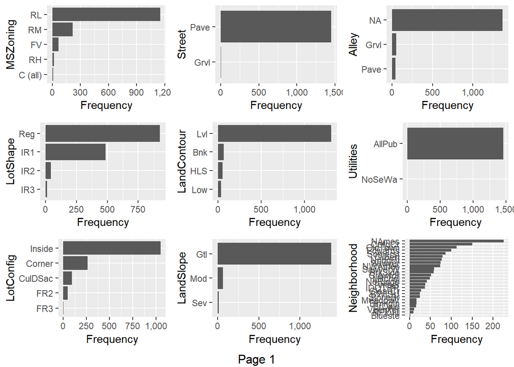

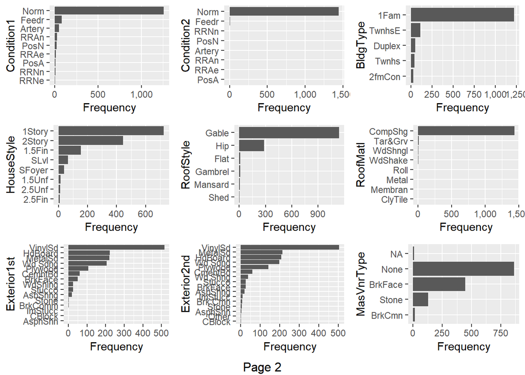

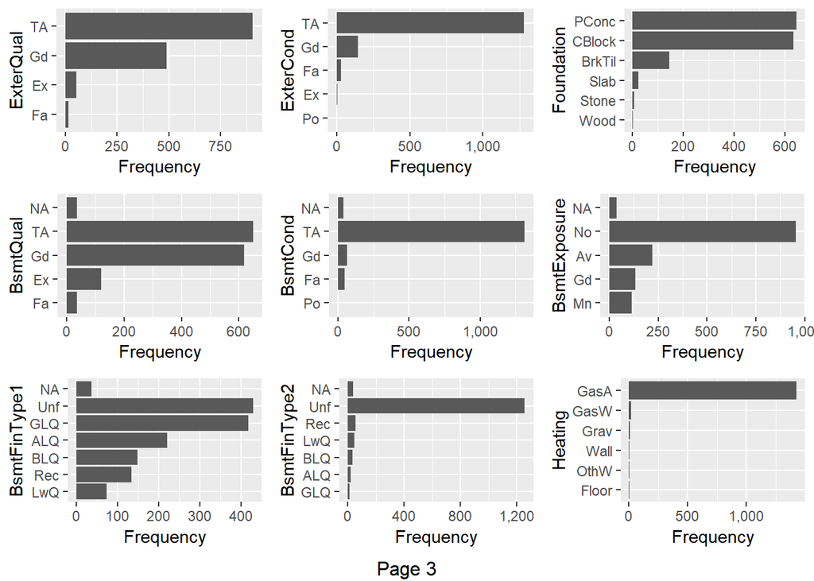

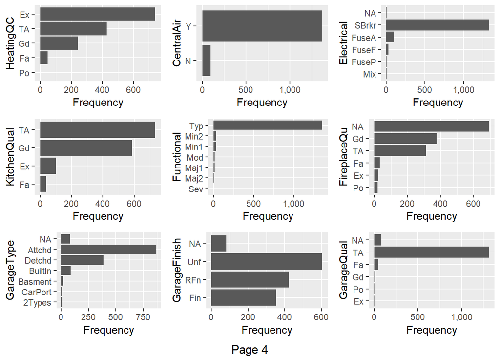

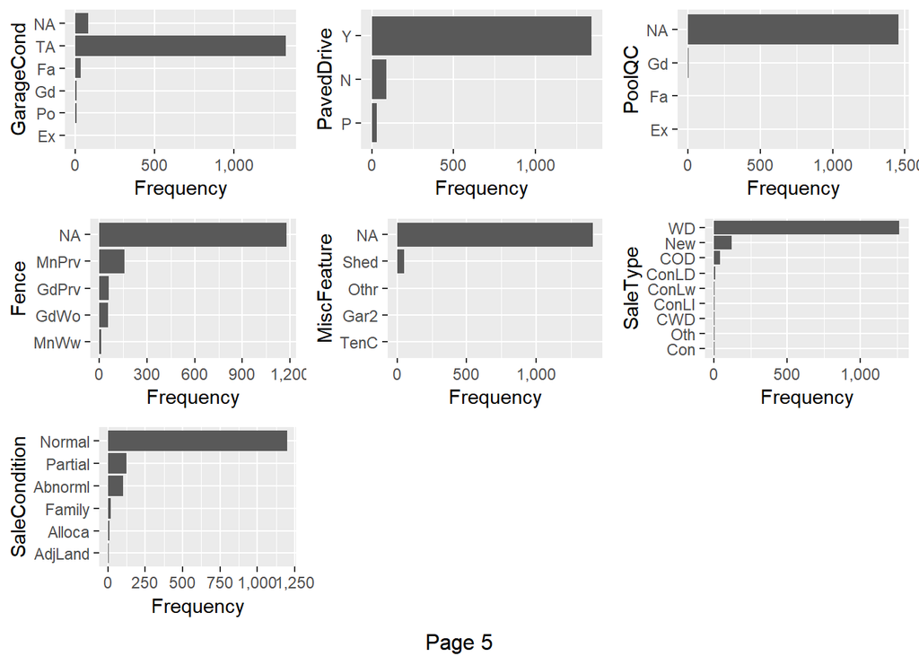

```r
plot_bar(train)
```

From the first look there are some features with many levels with no realy small values as:

- `Neighborhood`
- `Condition1`
- `Condition2`
- `HouseStyle`
- `RoofMatl`
- `Exterior1st`
- `Exterior2nd`
- `Functional`
- `SaleType`

## Continuos Features Overview

Now, let us check the continuos features

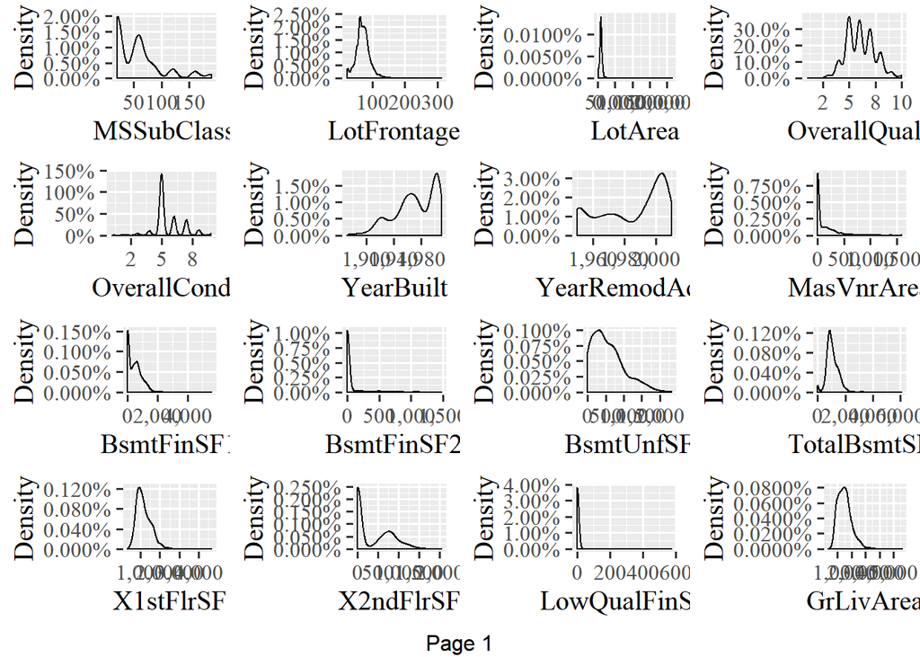

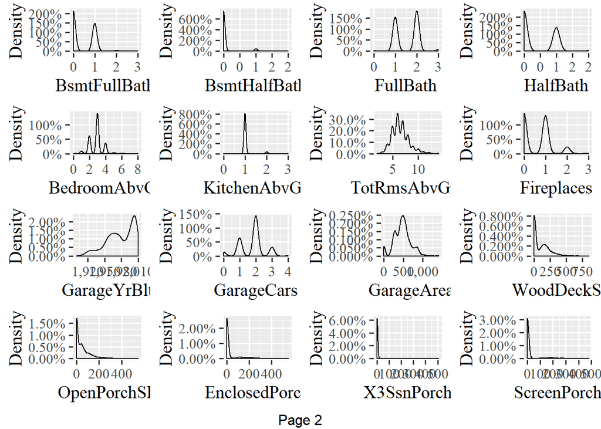

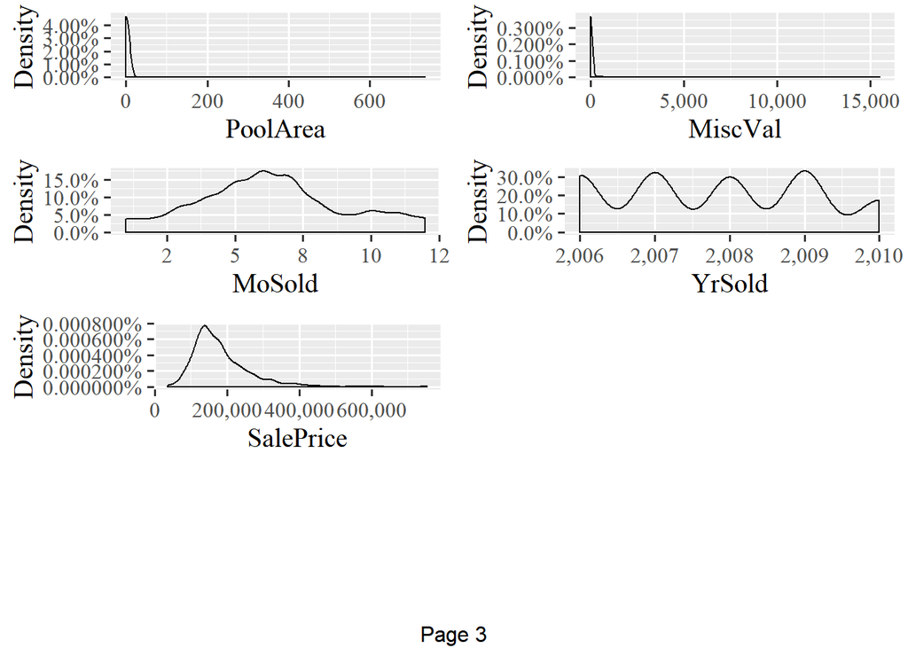

```r
plot_density(train[,-c(1)], ggtheme = theme_gray(base_size = 15, base_family = "serif"))
```

From plots, it seems there are many fluctations in many features and we will need to deal with each one of it individually.

## Resonse Variable Against Features Overview

Now, let us see how discreate and continuos features interact with the response variable first.

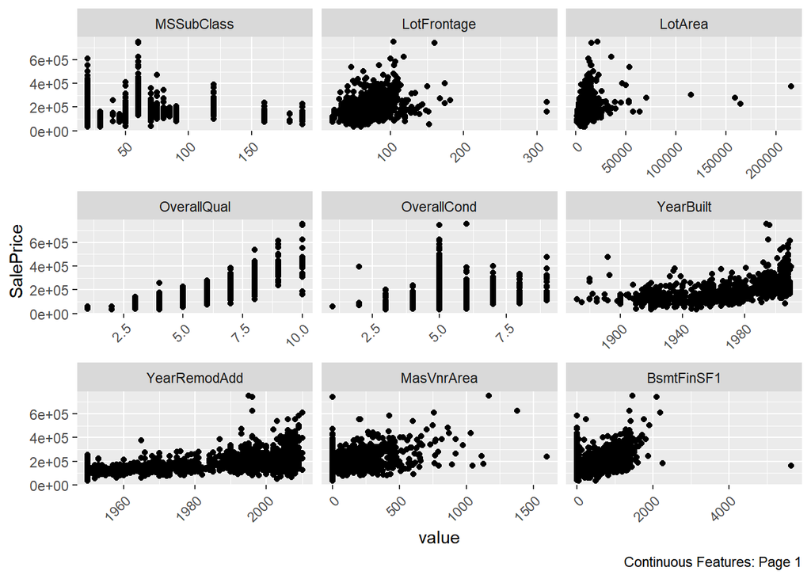

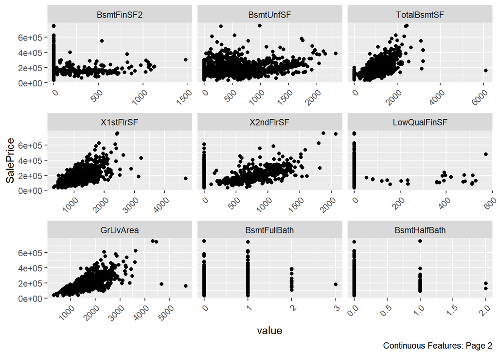

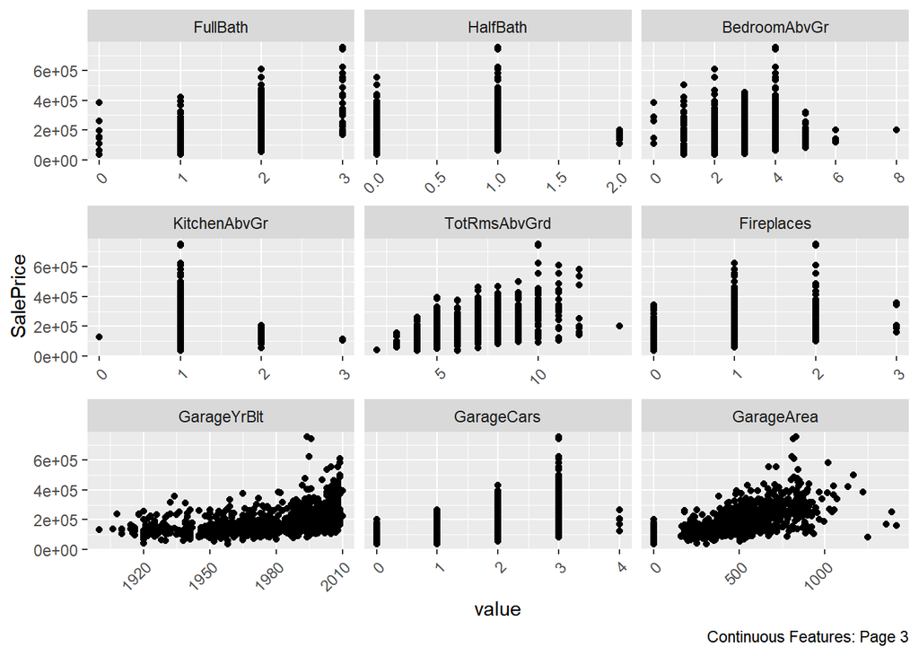

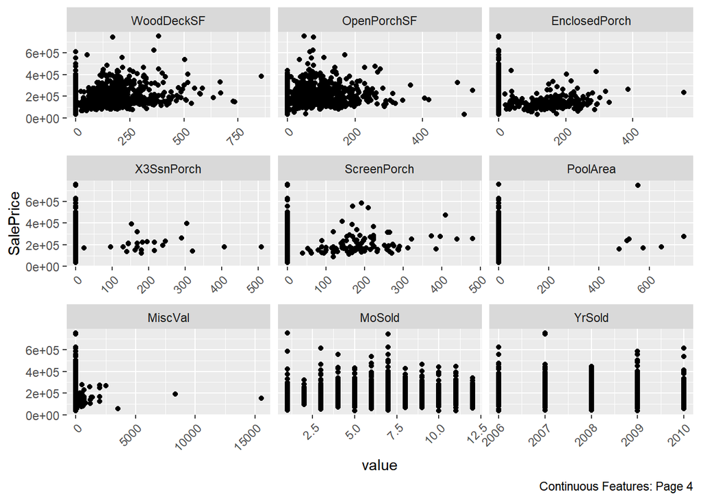

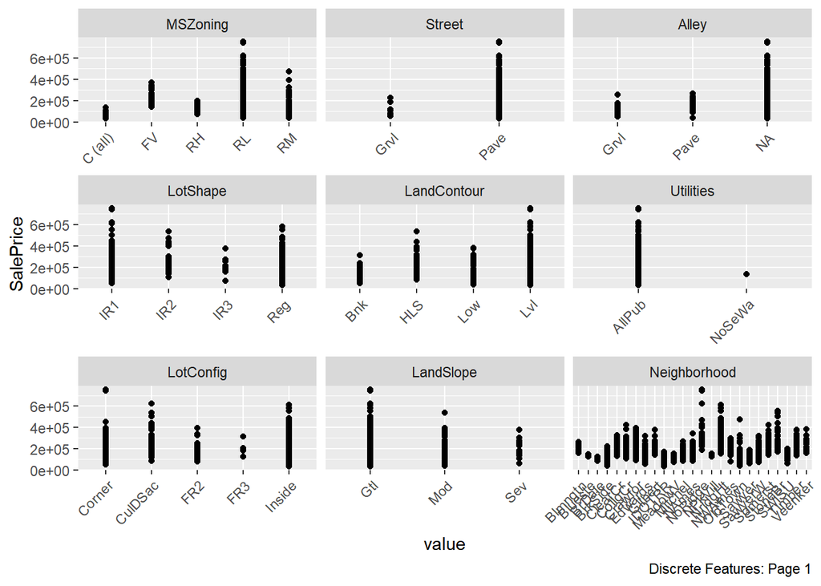

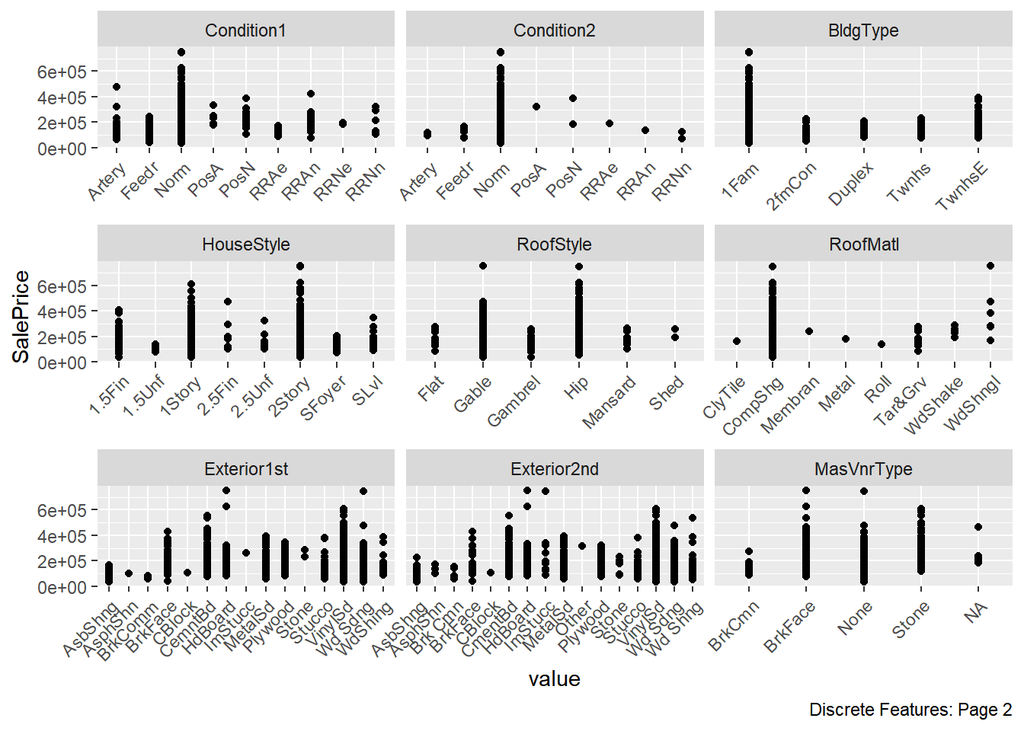

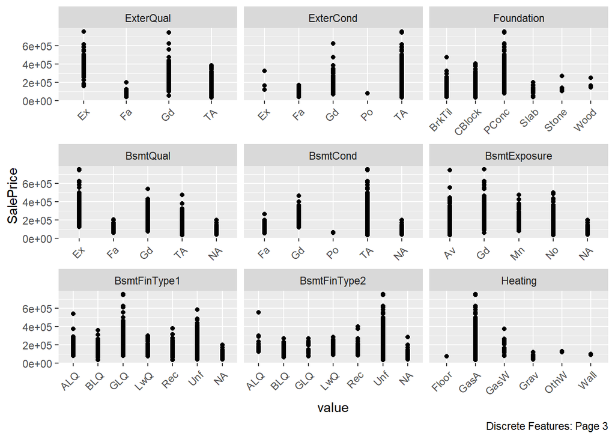

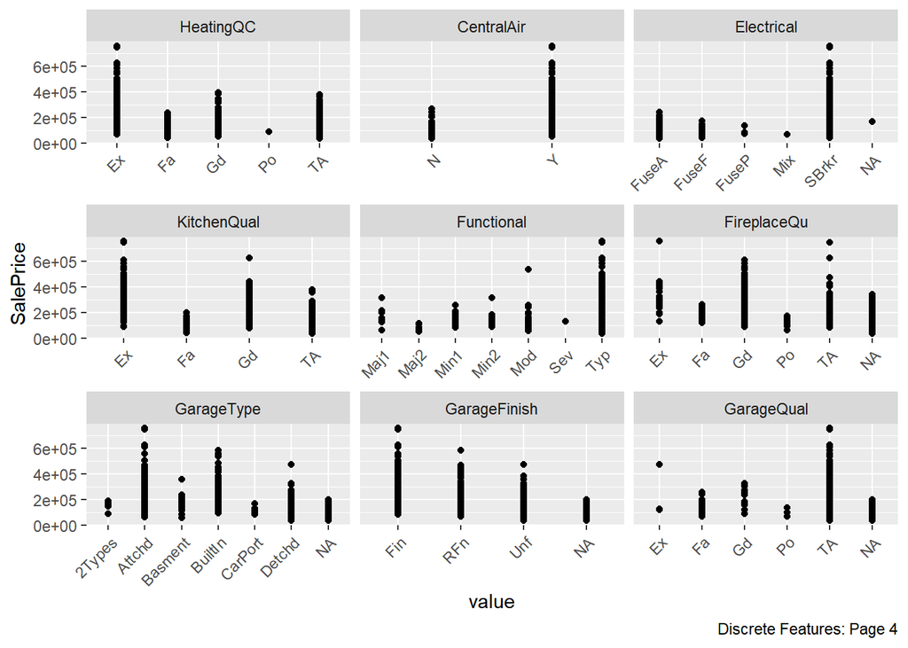

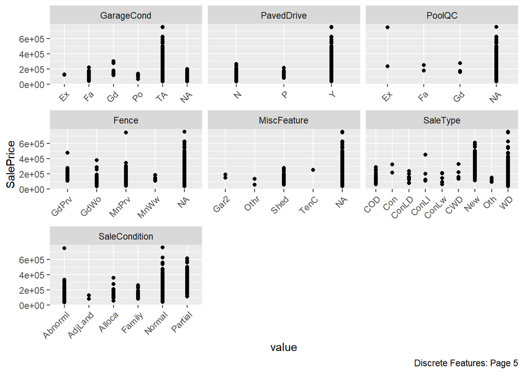

```r
plot_scatterplot(train[,-c(1)], by = "SalePrice")
```

The plots confirm my doubs about continuos features in specific, it needs serious handling. Now let us move to the final stage of our EDA, corrleation.

## Corrleation

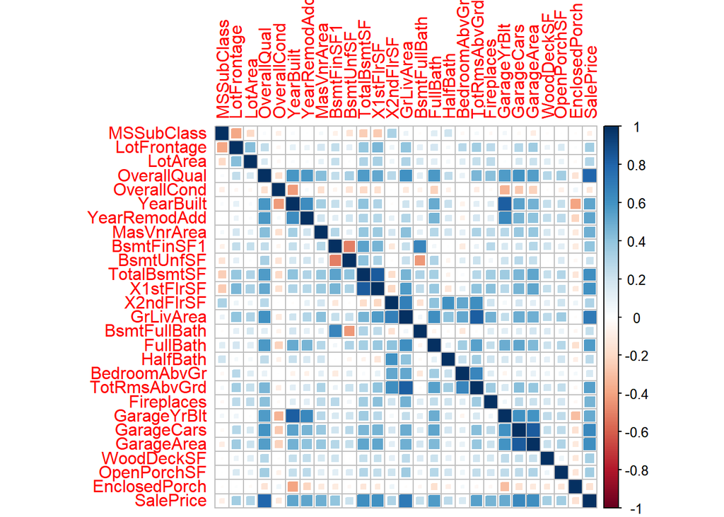

```r
numeric_var <- names(train)[which(sapply(train, is.numeric))]
correlations <- cor(na.omit(train[, numeric_var]))
# correlations
row_indic <- apply(correlations, 1, function(x) sum(x > 0.3 | x < -0.3) > 1)

correlations<- correlations[row_indic ,row_indic ]
corrplot(correlations, method="square")
```

It seems there is a high corrletation among continuos features, we will need to treat that in Feature Engineering phase.

### Plot scatter plot for variables that have high correlation.

The number of enclosed porches are negatively correlated with year built. It seems that potential housebuyers do not want an enclosed porch and house developers have been building less enclosed porches in recent years. It is also negatively correlated with SalePrice, which makes sense.

There is some slight negative correlation between OverallCond and SalePrice. There is also strong negative correlation between Yearbuilt and OverallCond. It seems to be that recently built houses tend to been in worse Overall Condition.

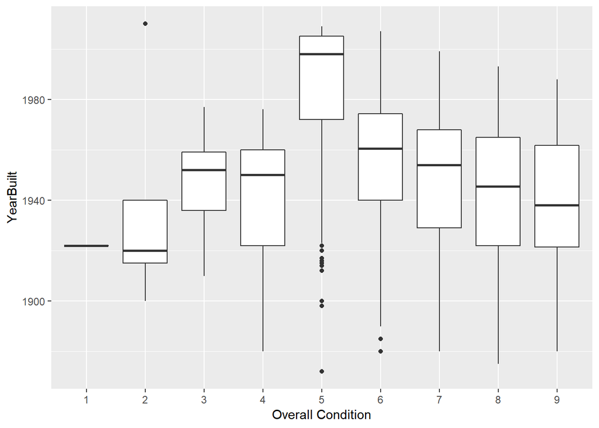

```r
train %>%
  select(OverallCond, YearBuilt) %>%
  ggplot(aes(as.factor(OverallCond),YearBuilt)) +
  geom_boxplot() +
  xlab('Overall Condition')
```